# AK-CSP-Aim1-7G8

```r
install.packages('stringdist')
install.packages("ggpubr")
library(dplyr)
library(reshape2)
#library(magrittr)
#library(reshape)
library(ggplot2)
#library(colorRamps)
#library(gplots)
library(RColorBrewer)
library(viridis)
#library(readr)
library(tidyverse)
library(ggpubr)

# Allows for user interaction with RStudio IDE
library(rstudioapi)
```

```r
setwd("/Users/akim/Documents/R-AK/AK-CSP-Aim1/")
print(getwd())
```

```
[1] "/Users/akim/Documents/R-AK/AK-CSP-Aim1"
```

```r
CSP_matrix = read.csv(file.path(getwd(),"/03_input/original/smoothedintensities_IGS_2016_7G8_ref_PF3D7_0304600.csv"))

### Create Output Folder by Variant Name ###
Pf_CSP_var <- "7G8"
```

Goal for Modular: Collate matrix by similarities in column names (NF54 or 7G8)

```r
# Selects first 4 columns of the data frame (constant for all .csv files)
LEFT_CSP <- select(CSP_matrix, Isolate, Amino.acid, Original.Position, Adjusted.Position)
#similar_header_pattern <- "^(\\w+)_\\d+$"
unique_headers <- unique(gsub(similar_header_pattern, "\\3", names(CSP_matrix)))
col_NF54 <- grep("NF54", names(CSP_matrix), value = TRUE) # All column headers w/ "NF54"
col_7G8 <- grep("7G8", names(CSP_matrix), value = TRUE) # All column headers w/ "7G8"
```

Sub-data frames – all NF54 CHMI AB’s

```r
df_NF54 <- cbind(LEFT_CSP, CSP_matrix[, col_NF54])
#print(new_df_NF54)
```

Sub-data frames – all 7G8 CHMI AB’s

```r
df_7G8 <- cbind(LEFT_CSP, CSP_matrix[, col_7G8])
```

[output not shown]

```r
#print(new_df_7G8)
```

```r
# Day 1
col_NF54_D1 <- grep("D1", names(df_NF54), value = TRUE) # All column headers w/ "D1" w/in df_NF54
col_7G8_D1 <- grep("D1", names(df_7G8), value = TRUE) # All column headers w/ "D1" w/in df_7G8

# Day 29
col_NF54_D29 <- grep("D29", names(df_NF54), value = TRUE) # All column headers w/ "D29" w/in df_NF54
col_7G8_D29 <- grep("D29", names(df_7G8), value = TRUE) # All column headers w/ "D29" w/in df_7G8
```

Sub-data frames – NF54 and 7G8 CHMI – parsed by Day1 or Day29 sera

```r
# NF54 - parsed by Day1, Day29 sera
df_NF54_D1 <- cbind(LEFT_CSP, df_NF54[, col_NF54_D1])
df_NF54_D29 <- cbind(LEFT_CSP, df_NF54[, col_NF54_D29])

# 7G8 - parsed by Day1, Day29 sera
df_7G8_D1 <- cbind(LEFT_CSP, df_7G8[, col_7G8_D1])
df_7G8_D29 <- cbind(LEFT_CSP, df_7G8[, col_7G8_D29])
#print(df_NF54_D1)
```

Take the average and standard deviation of 7G8 AB’s (DAY 29)

```r
# Returns value mean (of 7G8 -- Day29), as a column
mean_7G8_D29 <- rowMeans(df_7G8_D29[,col_7G8_D29], na.rm = TRUE)

# Calculate stddevs using apply()
std_df_7G8_D29 <- apply(df_7G8_D29[,col_7G8_D29], 1, sd, na.rm = TRUE)

# Calculate median for using apply()
median_df_7G8_D29 <- apply(df_7G8_D29[,col_7G8_D29], 1, median, na.rm = TRUE)
```

```r
# Appends mean values as last (right-most) column to 'df_7G8_D29' data frame
df_7G8_D29$row_means <- mean_7G8_D29

# Appends mean values as last (right-most) column to 'df_7G8_D29' data frame
#df_7G8_D29$row_median <- median_df_7G8_D29

# Appends std_dev values as last (right-most) column to 'df_7G8_D29' data frame
df_7G8_D29$SD <- std_df_7G8_D29
```

Find the serorecognition threshold

```r
df_7G8_D29_meanstdevthresh <- df_7G8_D29 %>%
    mutate("row_means" = mean_7G8_D29) %>% mutate("SD" = std_df_7G8_D29) %>%
  mutate("2.5stdev" = 2.5*SD) %>% mutate("threshold" = row_means + 2.5*SD)
```

Boxplot by position, no label

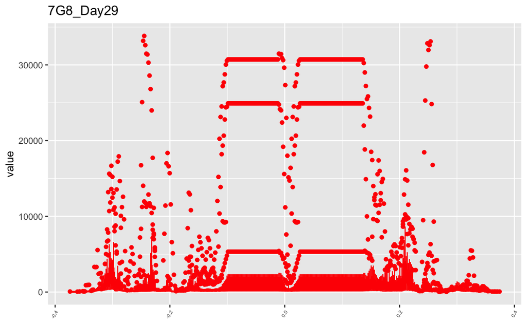

```r
# Per 'Adjusted.Position'
df_7G8_D29_box <- melt(df_7G8_D29[,c(4, 5:ncol(df_7G8_D29))], id.vars = "Adjusted.Position")
plot7G8_D29_BP <- ggplot(df_7G8_D29_box, aes(group = Adjusted.Position, y = value)) +
  geom_boxplot(color="red") +
  theme(axis.text.x = element_text(angle = 60, hjust = 1, size = 5)) +
  ggtitle("7G8_Day29")
plot7G8_D29_BP
```

```r
# Manually removing "outliers"

EDIT_df_7G8_D29 <- df_7G8_D29 %>% select(
    -M20UMD059_D29_7G8,
    -M20UMD024_D29_7G8,
    -M20UMD053_D29_7G8,
    -M20UMD045_D29_7G8,
    -M20UMD049_D29_7G8,
    -M20UMD011_D29_7G8,
    -M20UMD014_D29_7G8,
        )
```

EDIT_Boxplot by position, no label

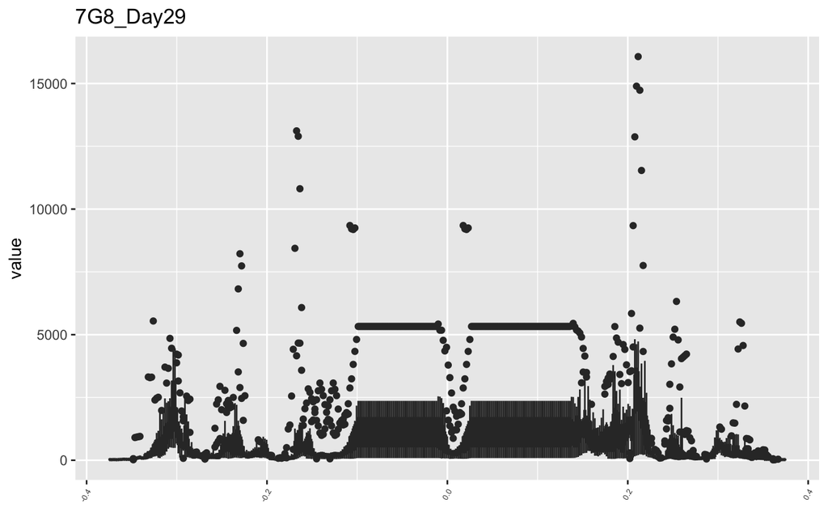

```r
# Per 'Adjusted.Position'
EDIT_df_7G8_D29_box <- melt(EDIT_df_7G8_D29[,c(4, 5:ncol(EDIT_df_7G8_D29))], id.vars = "Adjusted.Position")
ggplot(EDIT_df_7G8_D29_box, aes(group = Adjusted.Position, y = value)) +
  geom_boxplot() +
  theme(axis.text.x = element_text(angle = 60, hjust = 1, size = 5)) +
  ggtitle("7G8_Day29")
```

```r
# Manually removing "outliers" > 10000 FI

EDIT_df_7G8_D29 <- df_7G8_D29 %>% select(
    -M20UMD059_D29_7G8, # >10000 FI
    -M20UMD024_D29_7G8, # >10000 FI
    -M20UMD053_D29_7G8, # >10000 FI
    -M20UMD045_D29_7G8, # >10000 FI
    -M20UMD049_D29_7G8, # >10000 FI
    -M20UMD011_D29_7G8, # >10000 FI
    -M20UMD014_D29_7G8, # >10000 FI
    -M20UMD042_D29_7G8, # >5000
    -M20UMD038_D29_7G8, # >10000 (AA: ~350)
    -M20UMD044_D29_7G8, # >2000
    -M20UMD050_D29_7G8 # >10000 (AA: ~120)

        )
```

EDIT_Boxplot by position, no label

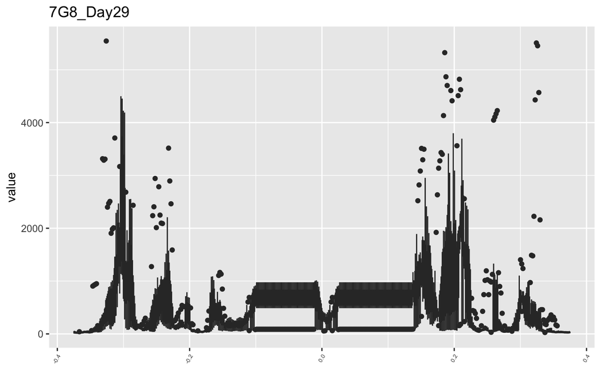

```r
# Per 'Adjusted.Position'
EDIT_df_7G8_D29_box <- melt(EDIT_df_7G8_D29[,c(4, 5:ncol(EDIT_df_7G8_D29))], id.vars = "Adjusted.Position")
ggplot(EDIT_df_7G8_D29_box, aes(group = Adjusted.Position, y = value)) +
  geom_boxplot() +
  theme(axis.text.x = element_text(angle = 60, hjust = 1, size = 5)) +
  ggtitle("7G8_Day29")
```

```r
# Returns value mean (of 7G8 -- Day29), as a column
mean_7G8_D1 <- rowMeans(df_7G8_D1[,col_7G8_D1], na.rm = TRUE)

# Calculate stddevs using apply()
std_df_7G8_D1 <- apply(df_7G8_D1[,col_7G8_D1], 1, sd, na.rm = TRUE)

# Calculate median for using apply()
median_df_7G8_D29 <- apply(df_7G8_D1[,col_7G8_D1], 1, median, na.rm = TRUE)
```

```r
# Appends mean values as last (right-most) column to 'df_7G8_D29' data frame
#df_7G8_D29$row_means <- mean_7G8_D29

# Appends mean values as last (right-most) column to 'df_7G8_D29' data frame
#df_7G8_D29$row_median <- median_df_7G8_D29

# Appends std_dev values as last (right-most) column to 'df_7G8_D29' data frame
#df_7G8_D29$SD <- std_df_7G8_D29
```

Find the serorecognition threshold

```r
df_7G8_D1_meanstdevthresh <- df_7G8_D1 %>%
    mutate("row_means" = mean_7G8_D1) %>% mutate("SD" = std_df_7G8_D1) %>%
  mutate("2.5stdev" = 2.5*SD) %>% mutate("threshold" = row_means + 2.5*SD)
```

Boxplot by position, no label

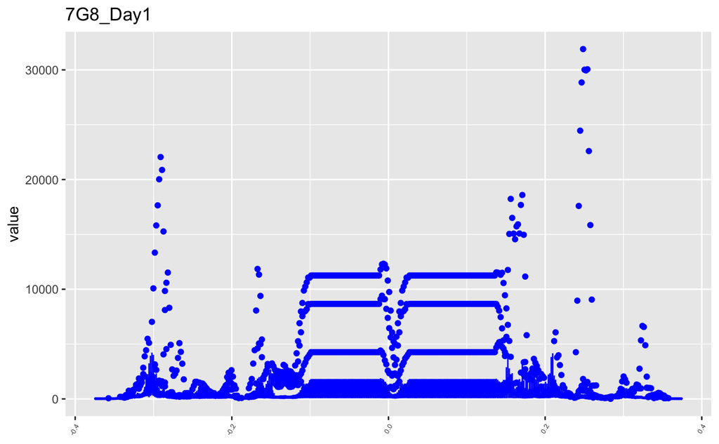

```r
# Per 'Adjusted.Position'
df_7G8_D1_box <- melt(df_7G8_D1[,c(4, 5:ncol(df_7G8_D1))], id.vars = "Adjusted.Position")
plot7G8_D1_BP <- ggplot(df_7G8_D1_box, aes(group = Adjusted.Position, y = value)) +
  geom_boxplot(color="blue") +
  theme(axis.text.x = element_text(angle = 60, hjust = 1, size = 5)) +
  ggtitle("7G8_Day1")
plot7G8_D1_BP
```

Both 7G8_Day29 and Day 1, no label

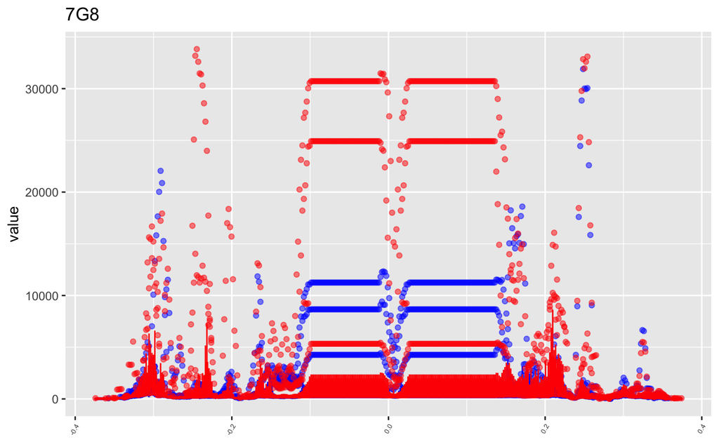

```r
# Per 'Adjusted.Position'
df_7G8_D1_box <- melt(df_7G8_D1[,c(4, 5:ncol(df_7G8_D1))], id.vars = "Adjusted.Position")
COMBOplot7G8_BP <- ggplot(df_7G8_D1_box, aes(group = Adjusted.Position, y = value)) +
  geom_boxplot(color="blue", alpha=0.5) +
  geom_boxplot(data = df_7G8_D29_box, color="red", alpha = 0.5) +
  theme(axis.text.x = element_text(angle = 60, hjust = 1, size = 5)) +
  ggtitle("7G8")
COMBOplot7G8_BP
```

Boxplot by position, no label - RAW

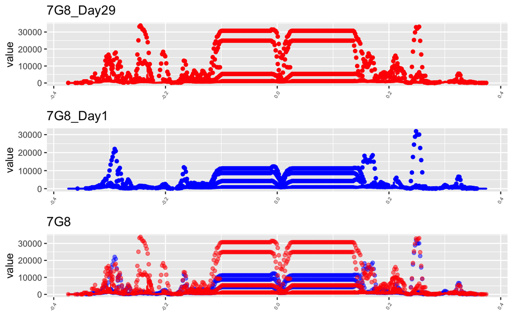

```r
ggarrange(plot7G8_D29_BP, plot7G8_D1_BP, COMBOplot7G8_BP,
         # labels = c("7G8_Day29", "7G8_Day1"),
          ncol = 1, nrow = 3)
```

###### NF54

Take the average and standard deviation of NF54 AB’s (DAY 29)

```r
# Returns value mean (of 7G8 -- Day29), as a column
mean_NF54_D29 <- rowMeans(df_NF54_D29[,col_NF54_D29], na.rm = TRUE)

# Calculate stddevs using apply()
std_df_NF54_D29 <- apply(df_NF54_D29[,col_NF54_D29], 1, sd, na.rm = TRUE)

# Calculate median for using apply()
median_df_NF54_D29 <- apply(df_NF54_D29[,col_NF54_D29], 1, median, na.rm = TRUE)
```

```r
# Appends mean values as last (right-most) column to 'df_7G8_D29' data frame
#df_7G8_D29$row_means <- mean_7G8_D29

# Appends mean values as last (right-most) column to 'df_7G8_D29' data frame
#df_7G8_D29$row_median <- median_df_7G8_D29

# Appends std_dev values as last (right-most) column to 'df_7G8_D29' data frame
#df_7G8_D29$SD <- std_df_7G8_D29
```

Find the serorecognition threshold

```r
df_NF54_D29_meanstdevthresh <- df_NF54_D29 %>%
    mutate("row_means" = mean_NF54_D29) %>% mutate("SD" = std_df_NF54_D29) %>%
  mutate("2.5stdev" = 2.5*SD) %>% mutate("threshold" = row_means + 2.5*SD)
```

Boxplot by position, no label

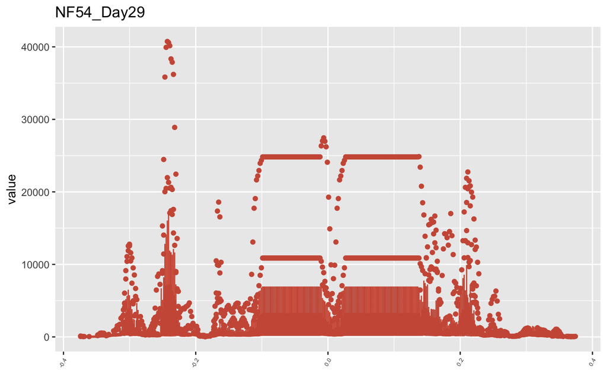

```r
# Per 'Adjusted.Position'
df_NF54_D29_box <- melt(df_NF54_D29[,c(4, 5:ncol(df_NF54_D29))], id.vars = "Adjusted.Position")
plotNF54_D29_BP <- ggplot(df_NF54_D29_box, aes(group = Adjusted.Position, y = value)) +
  geom_boxplot(color="coral3") +
  theme(axis.text.x = element_text(angle = 60, hjust = 1, size = 5)) +
  ggtitle("NF54_Day29")
plotNF54_D29_BP
```

Boxplot by position, no label

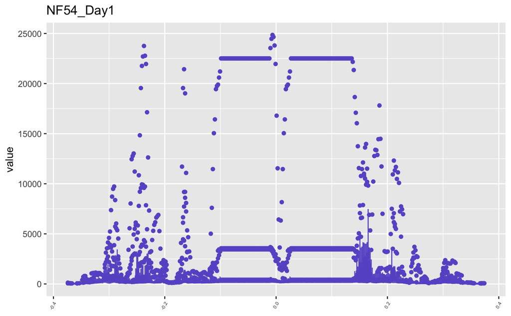

```r
# Per 'Adjusted.Position'
df_NF54_D1_box <- melt(df_NF54_D1[,c(4, 5:ncol(df_NF54_D1))], id.vars = "Adjusted.Position")
plotNF54_D1_BP <- ggplot(df_NF54_D1_box, aes(group = Adjusted.Position, y = value)) +
  geom_boxplot(color="slateblue") +
  theme(axis.text.x = element_text(angle = 60, hjust = 1, size = 5)) +
  ggtitle("NF54_Day1")
plotNF54_D1_BP
```

Both NF54_Day29 and Day 1, no label

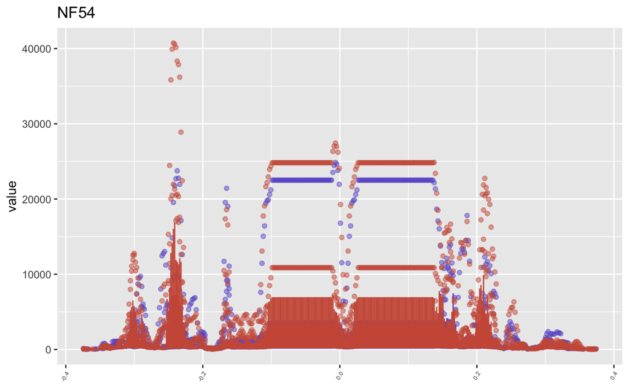

```r
# Per 'Adjusted.Position'
df_NF54_D1_box <- melt(df_NF54_D1[,c(4, 5:ncol(df_NF54_D1))], id.vars = "Adjusted.Position")
COMBOplotNF54_BP <- ggplot(df_NF54_D1_box, aes(group = Adjusted.Position, y = value)) +
  geom_boxplot(color="slateblue", alpha=0.5) +
  geom_boxplot(data = df_NF54_D29_box, color="coral3", alpha=0.5) +
  theme(axis.text.x = element_text(angle = 60, hjust = 1, size = 5)) +
  ggtitle("NF54")
COMBOplotNF54_BP
```

Boxplot by position, no label - RAW

```r
ggarrange(plotNF54_D29_BP, plotNF54_D1_BP, COMBOplotNF54_BP,
         # labels = c("7G8_Day29", "7G8_Day1"),
          ncol = 1, nrow = 3)
```

[output not shown]

Boxplot by position, no label - RAW

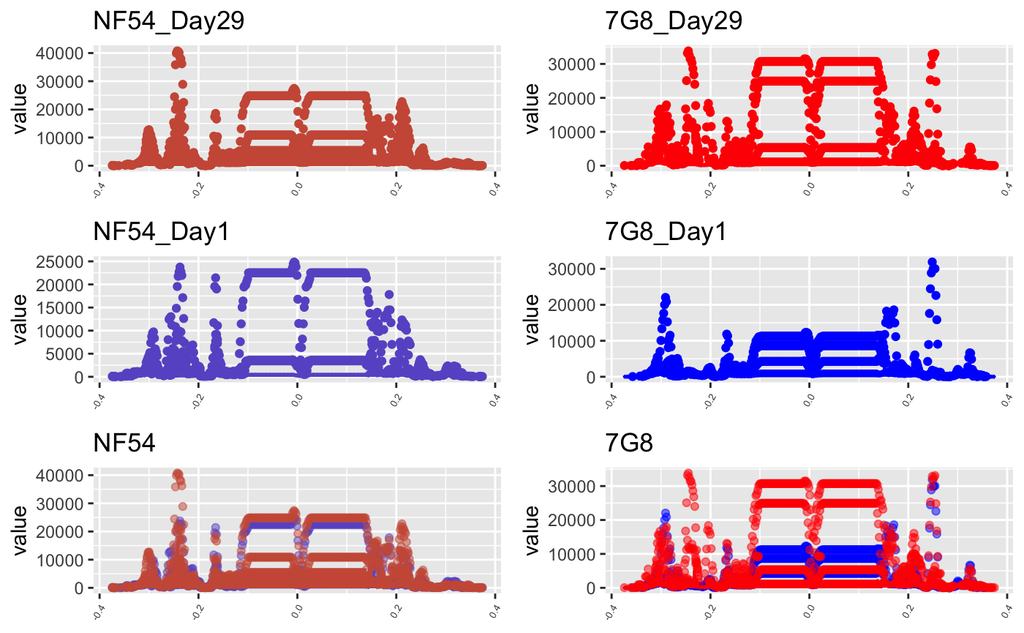

```r
ggarrange(plotNF54_D29_BP, plot7G8_D29_BP,
          plotNF54_D1_BP, plot7G8_D1_BP,
          COMBOplotNF54_BP, COMBOplot7G8_BP,
         # labels = c("7G8_Day29", "7G8_Day1"),
          ncol = 2, nrow = 3)
```